# Лабораторна робота №4

Варакута Олександр КІ-24-1

2025-06-02

# 1 Постановка завдання

Перевірити гіпотезу про нормальність розподілу вибірок $n=50$ та $n=1000$, обчислити числові характеристики (у тому числі стандартизовані значення асиметрії та ексцесу), побудувати графіки та створити власну функцію для форматованого виводу результатів.

# 2 Теоретичні відомості

**Нормальний розподіл:**

$$f(x)=\frac{1}{\sqrt{2\pi\sigma^2}} e^{-\frac{(x-\mu)^2}{2\sigma^2}}$$

де $\mu=0$, $\sigma=1$.

# 3 Розв’язання завдання

## 3.1 Генерація вибірок

```r
set.seed(123)
n1 <- 50
n2 <- 1000
X1 <- rnorm(n1, mean=0, sd=1)
X2 <- rnorm(n2, mean=0, sd=1)
```

## 3.2 Функція для обчислення характеристик

```r
calc_stats <- function(x) {
  n <- length(x)
  m <- mean(x)
  v <- var(x)
  s <- sd(x)
  skew <- skewness(x)
  kurt <- kurtosis(x)
  z_skew <- skew / sqrt(6/n)
  z_kurt <- kurt / sqrt(24/n)

  c(Середнє=m, Дисперсія=v, СКВ=s,
    Асиметрія=skew, Ексцес=kurt,
    Z_асиметрія=z_skew, Z_ексцес=z_kurt)
}

emp1 <- calc_stats(X1)
emp2 <- calc_stats(X2)
```

## 3.2 Таблиця характеристик

```r
kable(data.frame(
  Характеристика=names(emp1),
  Вибірка_50=round(emp1,4),
  Вибірка_1000=round(emp2,4)
), caption="Числові характеристики вибірок") %>%
  kable_styling(bootstrap_options = c("striped", "hover", "condensed"))
```

Числові характеристики вибірок

|  | Характеристика | Вибірка_50 | Вибірка_1000 |
| --- | --- | --- | --- |
| Середнє | Середнє | 0.0344 | 0.0230 |
| Дисперсія | Дисперсія | 0.8572 | 1.0070 |
| СКВ | СКВ | 0.9259 | 1.0035 |
| Асиметрія | Асиметрія | 0.1677 | 0.0841 |
| Ексцес | Ексцес | 2.5784 | 2.9655 |
| Z_асиметрія | Z_асиметрія | 0.4841 | 1.0857 |
| Z_ексцес | Z_ексцес | 3.7216 | 19.1419 |

## 3.3 Гістограми

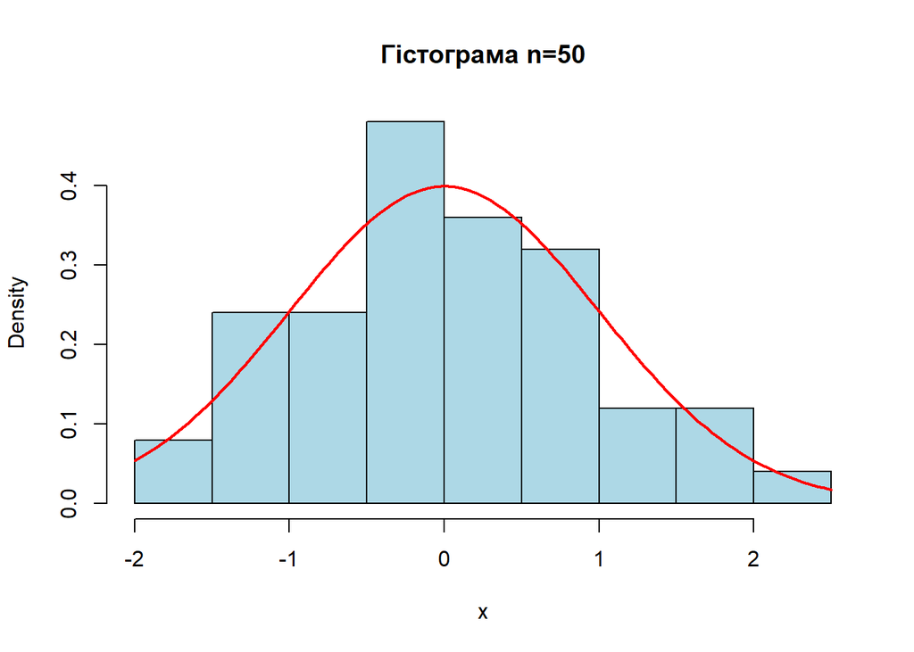

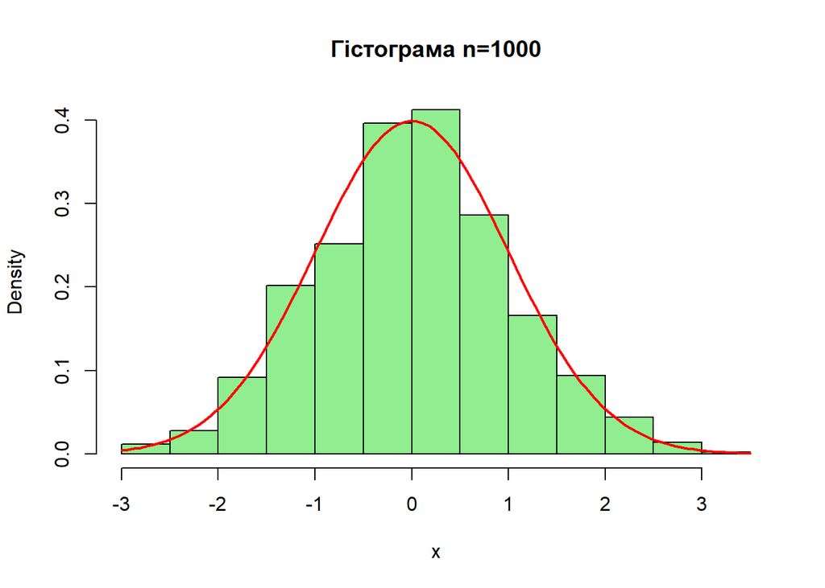

```r
hist(X1, probability=TRUE, col="lightblue", main="Гістограма n=50", xlab="x")
curve(dnorm(x,0,1), add=TRUE, col="red", lwd=2)

hist(X2, probability=TRUE, col="lightgreen", main="Гістограма n=1000", xlab="x")
curve(dnorm(x,0,1), add=TRUE, col="red", lwd=2)
```

## 3.4 Boxplot

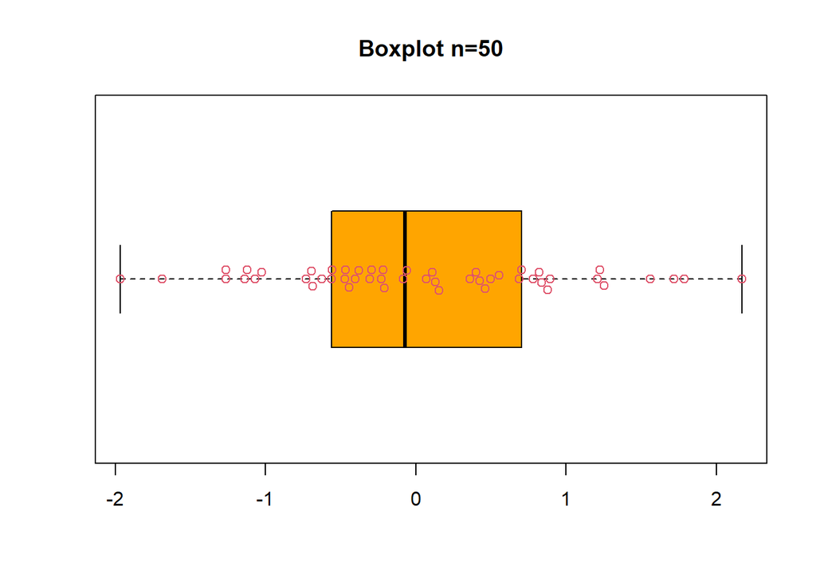

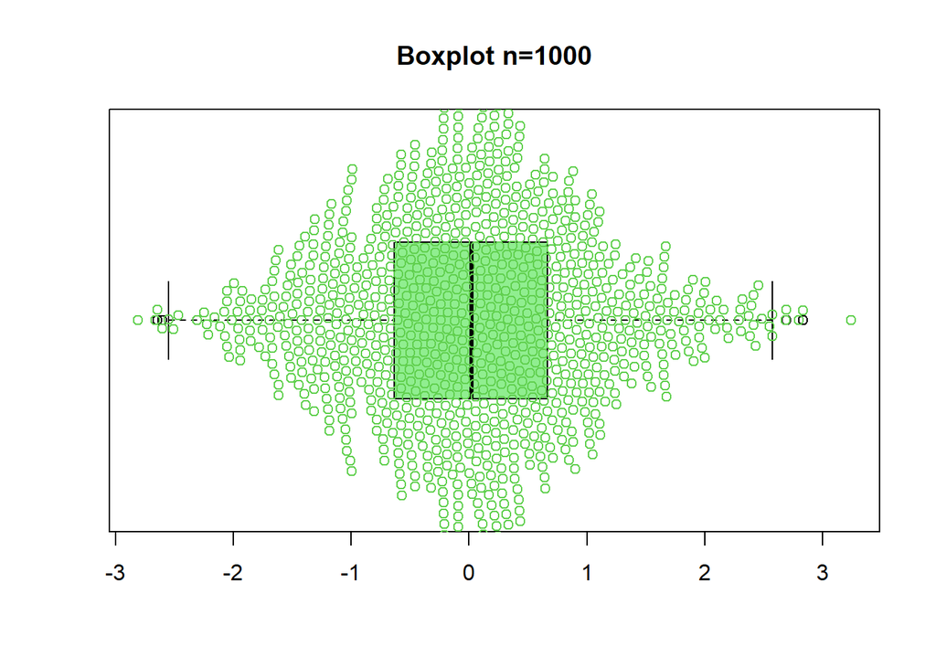

```r
boxplot(X1, main="Boxplot n=50", col="orange", horizontal=TRUE)
beeswarm(X1, add=TRUE, col=2, horizontal=TRUE)

boxplot(X2, main="Boxplot n=1000", col="lightgreen", horizontal=TRUE)
beeswarm(X2, add=TRUE, col=3, horizontal=TRUE)
```

## 3.5 Q-Q Plot

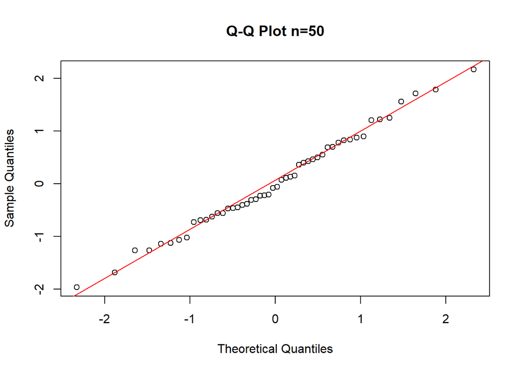

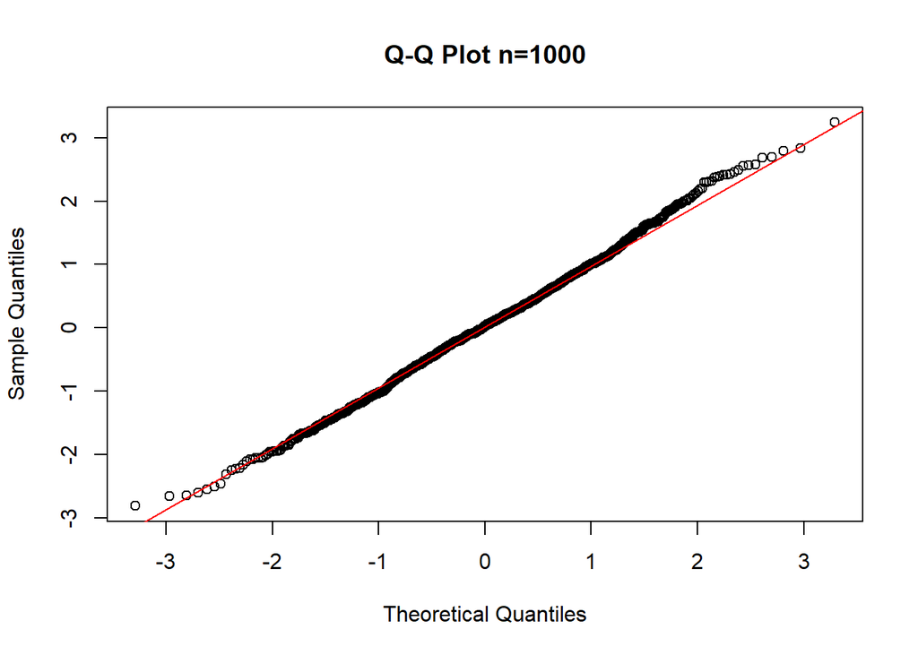

```r
qqnorm(X1, main="Q-Q Plot n=50")
qqline(X1, col="red")

qqnorm(X2, main="Q-Q Plot n=1000")
qqline(X2, col="red")
```

## 3.6 Перевірка нормальності

```r
check_normality <- function(x, alpha=0.05) {
  shapiro <- shapiro.test(x)
  ks <- ks.test(x, "pnorm", mean=mean(x), sd=sd(x))
  ad <- ad.test(x)

  verdict <- function(pval) {
    if (pval > alpha) "Нормальний" else "Ненормальний"
  }

  data.frame(
    Критерій = c("Shapiro-Wilk", "Kolmogorov-Smirnov", "Anderson-Darling"),
    p_значення = round(c(shapiro$p.value, ks$p.value, ad$p.value), 5),
    Результат = c(verdict(shapiro$p.value), verdict(ks$p.value), verdict(ad$p.value))
  )
}

check_normality(X1) %>%
  kable(caption = "Результати перевірки нормальності (n=50)") %>%
  kable_styling(bootstrap_options = c("striped", "hover", "condensed"))
```

Результати перевірки нормальності (n=50)

| Критерій | p_значення | Результат |
| --- | --- | --- |
| Shapiro-Wilk | 0.92786 | Нормальний |
| Kolmogorov-Smirnov | 0.85064 | Нормальний |
| Anderson-Darling | 0.85291 | Нормальний |

```r
check_normality(X2) %>%
  kable(caption = "Результати перевірки нормальності (n=1000)") %>%
  kable_styling(bootstrap_options = c("striped", "hover", "condensed"))
```

Результати перевірки нормальності (n=1000)

| Критерій | p_значення | Результат |
| --- | --- | --- |
| Shapiro-Wilk | 0.30107 | Нормальний |
| Kolmogorov-Smirnov | 0.90635 | Нормальний |
| Anderson-Darling | 0.31634 | Нормальний |

# 4 Виконання самостійного завдання

## 4.1 Функція для форматованого виводу та візуалізації

```r
print_stats <- function(x) {
  n <- length(x)
  m <- mean(x)
  v <- var(x)
  s <- sd(x)
  skew <- skewness(x)
  kurt <- kurtosis(x)
  z_skew <- skew / sqrt(6/n)
  z_kurt <- kurt / sqrt(24/n)

  cat("----- Вибірка (n =", n, ") -----\n")
  cat("Середнє:", round(m, 4), "\n")
  cat("Дисперсія:", round(v, 4), "\n")
  cat("СКВ:", round(s, 4), "\n")
  cat("Асиметрія:", round(skew, 4), "\n")
  cat("Ексцес:", round(kurt, 4), "\n")
  cat("Z-Асиметрія:", round(z_skew, 4), "\n")
  cat("Z-Ексцес:", round(z_kurt, 4), "\n\n")

  barplot(c(Середнє=m, СКВ=s, Асиметрія=skew, Ексцес=kurt),
          main=paste("Візуалізація (n=", n, ")", sep=""),
          col="skyblue", border="white")
}

print_stats(X1)
```

```
## ----- Вибірка (n = 50 ) -----
## Середнє: 0.0344
## Дисперсія: 0.8572
## СКВ: 0.9259
## Асиметрія: 0.1677
## Ексцес: 2.5784
## Z-Асиметрія: 0.4841
## Z-Ексцес: 3.7216
```

```r
print_stats(X2)
```

```
## ----- Вибірка (n = 1000 ) -----
## Середнє: 0.023
## Дисперсія: 1.007
## СКВ: 1.0035
## Асиметрія: 0.0841
## Ексцес: 2.9655
## Z-Асиметрія: 1.0857
## Z-Ексцес: 19.1419
```

[figure not shown]

[figure not shown]

# 5 Висновки

# 6 Відповіді на контрольні питання

**1 Які основні етапи перевірки статистичних гіпотез щодо закону розподілу і чому це важливо для статистичного аналізу?**

Основні етапи: - Формулювання нульової (H₀) та альтернативної (H₁) гіпотез. - Вибір відповідного статистичного тесту. - Обчислення тестової статистики та p-значення. - Прийняття або відхилення H₀. - Інтерпретація результату.

Це важливо, бо правильність тесту залежить від закону розподілу, що впливає на обґрунтованість статистичних висновків.

**2 Як використовувати R для визначення нормальності розподілу даних? Які функції або тести можна використовувати для цього?**

У R для перевірки нормальності: - Тести: `shapiro.test()`, `ks.test()`, `nortest::ad.test()`. - Показники форми: `moments::skewness()`, `moments::kurtosis()`. - Графіки: гістограми з теоретичною кривою, Q-Q plot (`qqnorm()`, `qqline()`).

**3 Як використовувати графічні методи, такі як QQ-графік, для оцінювання нормальності розподілу даних у R?**

Q-Q plot порівнює вибіркові та теоретичні квантілі:

```r
qqnorm(x)
qqline(x, col="red")
```

Прямолінійність точок = підтвердження нормальності.

** ️4 Які можливі наслідки або дії, якщо дані не відповідають припущенню про нормальний розподіл?**

- Можливі хибні результати в методах, що передбачають нормальність.
- Альтернатива: непараметричні тести (Медійний тест, тест Манна-Уїтні) або трансформація даних (логарифмічна, Box-Cox).

# 7 Перелік використаних джерел

- Документація R (`help(rnorm)`, `help(skewness)`, `help(shapiro.test)`)
- Методичні рекомендації
- Пакети `nortest`, `moments`